# EEMB 146 Final Report: Example with Palmer Penguin Data (change this to your own title- puns encouraged!)

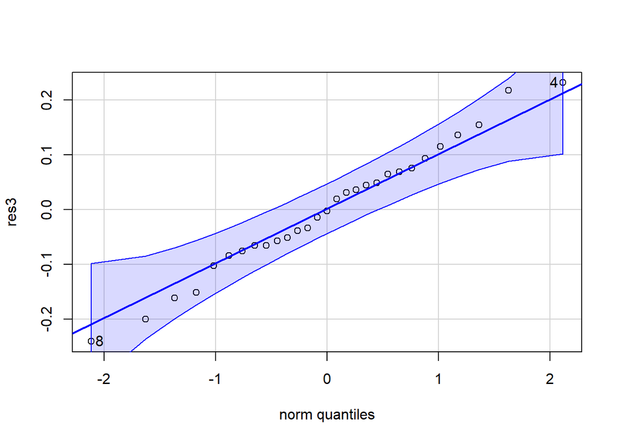

```
## [1] 8 4
```

```r
qqPlot(res3)
```

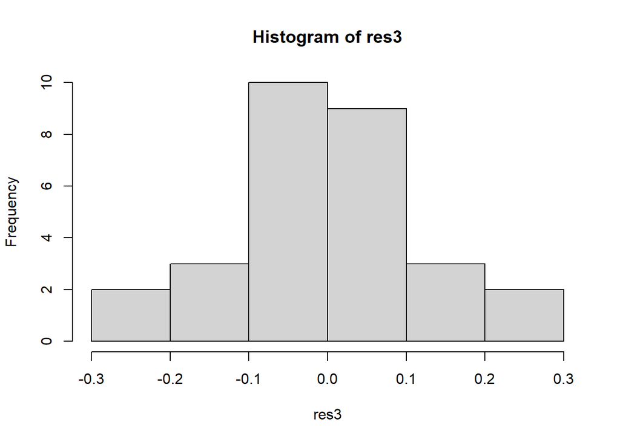

```r
hist(res3)
```

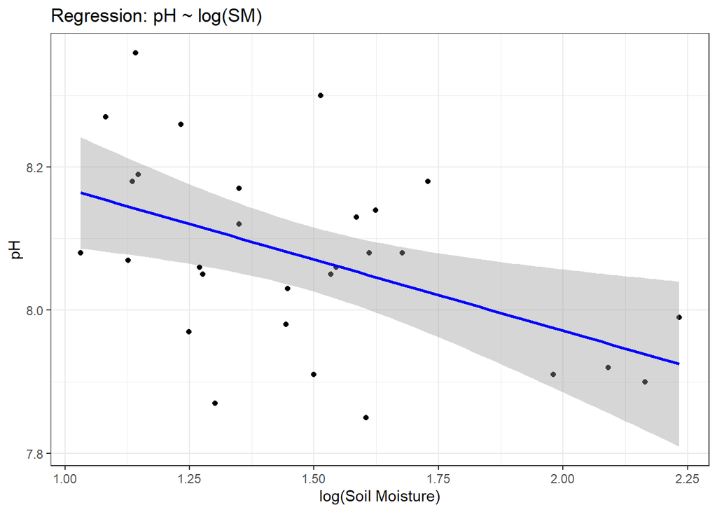

```r
ggplot(clean_data, aes(x = SM_log, y = pH)) +
  geom_point() +
  geom_smooth(method = "lm", col = "blue") +
  theme_bw() +
  labs(x = "log(Soil Moisture)", y = "pH", title = "Regression: pH ~ log(SM)")
```